# Homework 4: graphics practice

Kanyarat Suwannama  
2022-03-25

Here is this homework’s `R` `markdown` (`rmd`) file.

In our previous class demonstrations and homeworks, we practiced exploring Citi Bike ride data to gain insights into the bike share’s rebalancing efforts. In the process, we gained experience transforming data and mapping data to visual encodings. First, as a class we practiced using a workflow with Citi Bike data to create a new variable, an indicator whether bikes may have been rebalanced. Next, in homework two, we practiced mapping Citi Bike ride data onto the three attributes of color: hue, saturation, and luminance. In the process we were able to explore how useage, rebalancing efforts, or both may have changed between 2013 and 2019, and again before and after the pandemic began. This exploration also helped us consider some of the limitations of the particular visualization: it did not consider the effects of rebalancing or bike and docking station availability. In this assignment, we will try to account for those and other limitations in the visualizations, and in the process gain practice with new data graphics and *explaining* our insights to others.

**Opportunity alert**: In *previous* homeworks, I’ve given you most of the code and you’ve filled in the blanks. This time, I’m giving you an opportunity to write your own code for most of this assignment using what you’ve learned. The type of code you’ll need to write follows from past homeworks and class code demonstrations. If you get stuck, reviewing those should give you clues.

# Preliminary setup

Load libraries to access functions we’ll use in this analysis. Of note, if you have not installed these packages, do so outside of this `rmd` file.

```r
library(tidyverse) # the usual
library(geojsonio)   # for map data
library(broom)     # for map data
library(patchwork) # for organizing multiple graphs
library(ggthemes)  # collection of graph themes
theme_set(theme_tufte(base_family = 'sans'))
```

We’ll use the same dataset as in our previous homework. Let’s load our data and rename variables (as before),

```r
rider_trips <- read_csv('data/201909-Citi Bike-tripdata.csv')
rider_trips <-
  rider_trips %>%
  rename_all(function(x) gsub(' ', '_', x)) %>%
  rename(start_time = starttime,
         end_time = stoptime) %>%
  mutate(tripduration = as.difftime(tripduration, units = 'hours') )
```

Previously, we considered that, in general, Citi Bike’s available data include measures of several attributes for each bike ride. When a bikeshare customer begins their ride, Citi Bike measures these attributes,

```
bikeid
start_station_id
start_station_name
start_station_longitude
start_station_latitude
start_time
```

For the same record (row in the data), when a bikeshare customer ends their ride, Citi Bike measures additional attributes:

```
end_station_id
end_station_name
end_station_longitude
end_station_latitude
end_time
```

We’ll also use the variable `usertype`, and the calculated variable `tripduration`. Of note, while Citi Bike also records other attributes about the ride (*e.g.*, `birthyear`, `gender`), we’ll ignore these here.

Thus, for customer rides, any given ride begins at the same station that the previous ride ended. Described with math, for rides $n \in 1, 2, ... N$ of each bike $b \in 1, 2, ... B$, we can express bike location between rides as

$$\textrm{end_station_name}_{b, n} = \textrm{start_station_name}_{b,
n+1} \mid \textrm{normal usage}$$

This does not always hold, however, when Citi Bike intervenes between rides by removing a bike from a docking station for whatever reason (*e.g.*, rebalancing or repair); Citi Bike may redock the bike anywhere or not at all. By combining information for ride $n$ and $n+1$, we can create *intervention* observations and by filtering to only keep transitions where

$$\textrm{end_station_name}_{b, n} \ne \textrm{start_station_name}_{b,
n+1} \mid \textrm{intervention}$$

# Question 1 — measuring CitiBike interventions (data transformations)

Create observations for Citi Bike’s interventions. To create these, you’ll need to perform several data transformations.

Here’s my suggestion. First, arrange the data by `bikeid` and `start_time`, so that each bike’s rides will be ordered in time. Then, group all observations for each `bikeid` together. Within these groupings (by `bikeid`), you’ll create a new observation describing the time between rides. Thus, for each of the original variables with names that begin with `start_` or `end_`, the `start_` variables in your new intervention observations should be equal to the original `end_` variables of the previous observed ride, and 2) the new `end_` variables are equal to original `start_` variables of the current observed ride.

Now for most of those new intervention observations, the `start_` and `end_` variables will be the same because the bike just stays docked until the next ride. Filter those out, and you’ll be left with rides where Citi Bike, for whatever reason, moved the bike between rides.

Of note, you won’t know where the previous ride was from for the first ride (using only this data), so that’s missing data. For this exercise, assume no rebalancing occured before the first ride. Filter those out. Include the variable `usertype` and set its measurement for all these intervention observations to “Citi Bike”. Finally, calculate the time difference between start and end of the transition in units of *hours*, and save as `tripduration`. Hint: you might try coding something like `difftime(end_time, start_time, units = 'hours')`.

Your new data frame should include these variables:

```
bikeid
start_station_id
start_station_name
start_station_longitude
start_station_latitude
start_time
end_station_id
end_station_name
end_station_longitude
end_station_latitude
end_time
usertype
tripduration
```

Name your new dataframe as the object `interventions`.

```r
# ENTER CODE TO TRANSFORM DATA INTO interventions

interventions <-
  rider_trips %>%
  select(bikeid,
start_station_id,
start_station_name,
start_station_longitude,
start_station_latitude,
start_time,
end_station_id,
end_station_name,
end_station_longitude,
end_station_latitude,
end_time,
usertype,
tripduration) %>%

  arrange(bikeid, start_time) %>%
  group_by(bikeid) %>%
  filter(start_station_id != lag(end_station_name))  %>%
  mutate(interventions  = if_else(row_number() > 1 & start_station_id != lag(end_station_id),TRUE, FALSE)) %>%

  filter(interventions == TRUE) %>%

           mutate(end_station_id = start_station_id,
         end_station_name = start_station_name,
         end_station_longitude = start_station_longitude,
         end_station_latitude = start_station_latitude,
         end_time = start_time) %>%

  mutate(start_station_id = lag(end_station_id),
         start_station_name = lag(end_station_name),
         start_station_longitude = lag(end_station_longitude),
         start_station_latitude = lag(end_station_latitude),
         start_time = lag(end_time)) %>%

           mutate(tripduration = round(difftime(end_time, start_time, units = 'hours'), 0)) %>%

    drop_na() %>%

  ungroup() %>%

  select(bikeid,
start_station_id,
start_station_name,
start_station_longitude,
start_station_latitude,
start_time,
end_station_id,
end_station_name,
end_station_longitude,
end_station_latitude,
end_time,
usertype,
tripduration)
```

How many observations are in your new data frame `interventions`?

```r
nrow(interventions)
```

```
[1] 33909
```

```r
'33909 observations'
```

```
[1] "33909 observations"
```

# Question 2 — visualizing time between rides (visually encoding data)

Applying the grammar of graphics with `ggplot2`, 1) create a histogram of your calculated `tripduration` in your new data frame `interventions`, 2) layer a red, vertical line onto the histogram that marks `24` hours, and 3) add *explanatory* information including `x` and `y` labels, your main takeaway as a `title`, and a `caption` describing the source of your data.

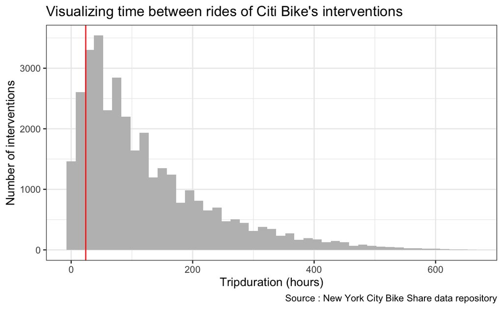

```r
# ENTER CODE TO GRAPH YOUR tripduration INTERVENTION DATA

library(ggplot2)
library(tidyverse)
library(dplyr)

interventions %>%
  ggplot() +
  geom_histogram(mapping = aes(x = tripduration), binwidth = 15, fill = "grey"
  ) +
  geom_vline(
    mapping = aes(
      xintercept = 24
    ),
    color = "red",
    size = 0.5
  ) +
  labs(
    title = "Visualizing time between rides of Citi Bike's interventions",
    caption =
      str_c("Source : New York City Bike Share data repository"),
    x = "Tripduration (hours)",
    y = "Number of interventions"
    ) +

theme_bw()
```

# Question 3 — communication, critical thinking

Does our above method (creating observations when the `end_station_id` of a ride does not match the `start_station_id` of the consecutive ride) tend to accurately measure how often Citi Bike has intervened, or might our method tend to overcount or undercount? Explain to a Citi Bike analytics executive.

> The interventions rows are the movement where the bike was moved between rides from one location to another (e.g., rebalancing or repair). The end time for interventions will be the start time of the current row and similarly start time for interventions will be the end_time of the previous row.We know that rebalancing must have occurred in a window of time: between the end time of its previous trip and the start time of the subsequent trip. However, the way we account for Citi Bike rebalacing effort is purely filtering the bike that have end and start station that are not matching. Moreover, Citi Bike intervenes to rebalance docking stations in many ways, including Motorized Vehicles for long-distance rebalancing, Bike Trains with a “train” carriage at the end that can carry 12–16 bikes, and Valet Schedule for expanded bike and dock availability at high-volume stations during peak periods. Also, the Bike Angels program, the Citi Bike riders who are willing to returning the bikes at particular stations and improve the availability of bikes and docks for fellow riders while earn back the rewards. However, our data are counted those Bike Angels rebalancing trips as regular trips from one station to another station. This is not considered if we are only looking into unmatch end station and start station. Hence, our method is likely to undercount the actual intervention trips.

# Question 4 — communication, critical thinking

Apple Maps estimates that on average a bike ride from the top of Manhattan (Inwood Hill Park) to the bottom of Manhattan (Battery Park) would take about 1.5 hours. And some *bike angels* can ride pretty fast! Obviously Citi Bike may intervene to rebalance docking stations, and in our earlier discussions we discussed four ways they try to rebalance. Consider reasons other than rebalancing where Citi Bike may intervene. Does your histogram suggest anything about Citi Bike’s methods and purposes for their interventions? Explain to a Citi Bike analytics executive.

# Question 5 — visualize location of interventions (visually encoding data)

To practice layering encodings onto maps, let’s try to uncover high-level patterns in the location of Citi Bike interventions.

We might think of these interventions geographically (that is, locations in space). First, to visualize these interventions as locations in space, we’ll overlay visual encodings onto a map of Manhattan. We can create the base map from geographic data available at [Beta NYC](https://beta.nyc/products/boundaries-map/), which we convert from the available data structure called a *spatial polygon data frame*, into a regular data frame of which we are familiar. Here’s the code:

```r
# identify the filename and location relative to the project directory
map_file <- 'data/betanyc_hoods.geojson'

# save and load the geojson as a spatial polygon data frame
if( !file.exists(map_file) ) {
  url <- str_c(
    'https://ssp3nc3r.github.io/',
    '20213APAN5800K007/data/betanyc_hoods.geojson'
    )

  # below functions in geojsonio package
  spdf <- geojson_read(url, what = 'sp')
  geojson_write(spdf, file = map_file)

} else {
  spdf <- geojson_read(map_file, what = 'sp')
}

# convert the spatial polygon data frame to tibble (data.frame) for
# boroughs and neighborhoods using the tidy function (broom package)
nyc_neighborhoods <- tidy(spdf, region = 'neighborhood')
nyc_boroughs <- tidy(spdf, region = 'borough')
```

Inspect both the spatial polygon data frame, `spdf`, and the two new regular data frames, `nyc_neighborhoods` and `nyc_boroughs` to get a sense of how they are structured.

From these data frames, we draw a base map of Manhattan that also shows its neighborhood boundaries. Review the help file for `geom_polygon`, the function we’ll use to map this spatial data onto visual encodings. Again, here’s some code to create our base map:

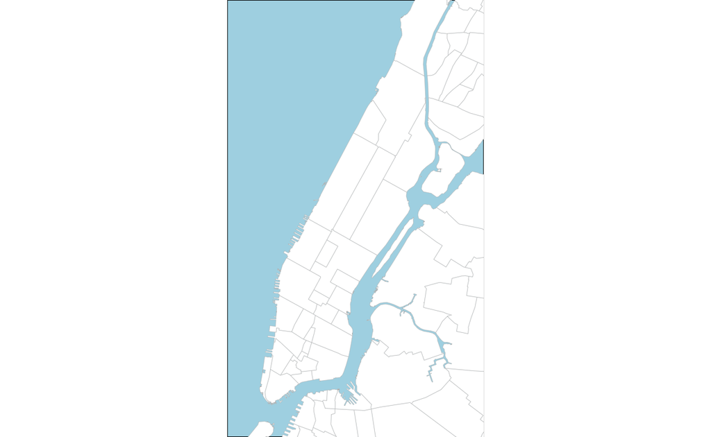

```r
p_hoods <-

  # initialize graph
  ggplot() +

  # remove most non-data ink
  theme_void() +

  # add color for water (behind land polygons)
  theme(
    panel.background = element_rect(fill = 'lightblue')
  ) +

  # define coordinate system and zoom in on Manhattan
  coord_map(
    projection = 'mercator',
    xlim = c(-74.03, -73.91),
    ylim = c( 40.695, 40.85)
  ) +

  # map boundary data to visual elements (polygons)
  geom_polygon(
    data = nyc_neighborhoods,
    mapping = aes(
      x = long,
      y = lat,
      group = group
    ),
    fill = 'white',
    color = 'gray',
    lwd = 0.1
  )

# display the graph
p_hoods
```

There are many approaches to encode intervention data onto visual variables layered onto the map. Choose one or more visual encodings to layer intervention data onto the map. These may be visually encoded from direct observations in `interventions`, *from transformations or summaries* of those observations, or from *both*.

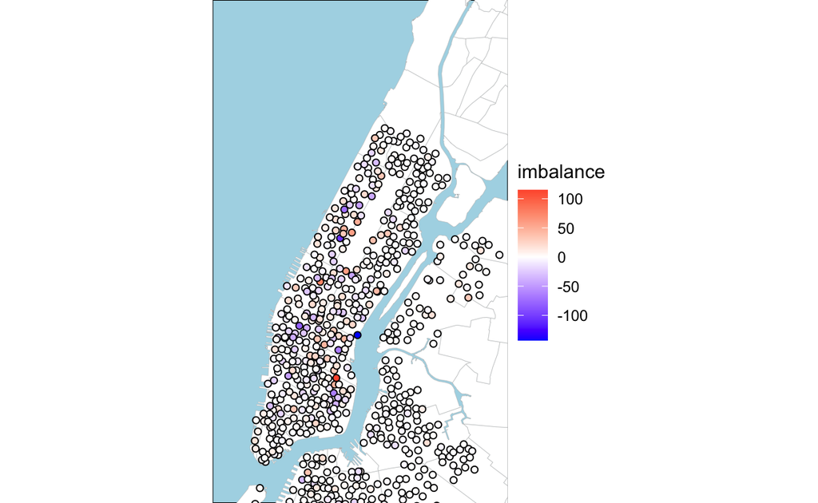

```r
# ENTER CODE TO LAYER YOUR INTERVENTION DATA ONTO MAP
station_balance <-
  interventions %>%
  pivot_longer(
    cols = c(start_station_id, end_station_id),
               names_to = "start_end",
               values_to = "station_id") %>%
group_by(station_id) %>%
  summarise(
    imbalance = sum( if_else(start_end == "start_station_id", -1, +1) )
  ) %>%
  ungroup() %>%

 right_join(
    interventions %>%
    select(
      `start_station_id`,
      `start_station_longitude`,
      `start_station_latitude`) %>%
    unique(),
    by = c("station_id" = "start_station_id")
  )

p_hoods +
    scale_fill_gradient2(low = 'blue', mid = 'white', high = 'red') +
  geom_point(
    data = station_balance,
    mapping = aes(
      x = `start_station_longitude`,
      y = `start_station_latitude`,
      fill = imbalance
    ),
    shape = 21,
    color = 'black',
    size = 1.5,
    lwd = 0.1
  )
```

Explain to a Citi Bike analytics executive, *what* were your choices of visual encodings and *how* they help the executive explore patterns in Citi Bike interventions?

# Question 6 — combine ride data with CitiBike interventions (data transformation)

Combine your new observations from `interventions` with the original observed rides in `rider_trips` into a new data frame called `allmoves`.

```r
# ENTER CODE TO COMBINE OR BIND ROWS FROM rider_trips AND interventions

interventions <- interventions %>%
  mutate(normalride_intervention = "intervention")

allmoves <- rider_trips %>%
    select(bikeid,
start_station_id,
start_station_name,
start_station_longitude,
start_station_latitude,
start_time,
end_station_id,
end_station_name,
end_station_longitude,
end_station_latitude,
end_time,
usertype,
tripduration) %>%
  mutate(normalride_intervention = "normal")  %>%
  rbind(interventions)
```

# Question 7 — estimating number of bikes at stations (data transformation)

Next, let’s look more closely at the patterns of bikes available at a station across time. Again, we don’t directly have the number of bikes or number of empty parking spots available at each station at any given time, but we can estimate that information from the above data. With your data frames `rider_trips` and `interventions` (or collectively, `allmoves`), within each `station_id` you can count observed rides (and interventions): each `end_station_id` counts as `+1`, and each `start_station_id` counts as `-1`.

Then, you can order them in time and use a *cumulative sum* function like `cumsum()`. Because our data arbitrarily begins at the beginning of a month, however, we should not be starting our cumulative counts at `0` (because there were already bikes at the stations). We can account for this by subtracting from the cumulative bikes the minimum at each station over the month: *e.g.*, $\sum b_i - \textrm{min}(\sum b_i)$, where $b_i \in [-1, +1]$.

In the step of transforming data, calculate this across time per station for 1) your combined trips and interventions and 2) separately for just interventions.

```r
# ENTER CODE TO TRANSFORM DATA (ACCUMULATED SUMS OF BIKES ENTERING & LEAVING)

accumulated_allmoves <-
  allmoves %>%
   pivot_longer(
    cols = c(start_station_id, end_station_id),
    names_to = 'start_end',
    values_to = 'station_id') %>%
  group_by(station_id) %>%
  arrange(start_time) %>%
  mutate(entering_leaving = if_else(start_end == "start_station_id", -1, +1) ) %>%
  mutate(bikes_cum = cumsum(entering_leaving)) %>%
  mutate(total_cum = bikes_cum - min(bikes_cum))

accumulated_interventions <-
  interventions %>%
  pivot_longer(
    cols = c(start_station_id, end_station_id),
    names_to = "start_end",
    values_to = "station_id") %>%
  group_by(station_id) %>%
  arrange(start_time) %>%
  mutate(entering_leaving = if_else(start_end == "start_station_id", -1, +1) ) %>%
  mutate(bikes_cum = cumsum(entering_leaving)) %>%
  mutate(total_cum = bikes_cum - min(bikes_cum))
```

In the step of visually encoding the transformed data, graph the two cumulative sums of all across time at one particular station: “W 31 St & 7 Ave”, which is near Penn Station. Categorically encode the cumulative sum of combined trips and interventions in *black*, and encode the cumulative sum of just interventions in *red*.

```r
# ENTER CODE TO GRAPH BOTH ACCUMULATED SUMS FOR THE SINGLE STATION

allmoves  %>%
    filter(start_station_name == 'W 31 St & 7 Ave') #The station_id of 'W 31 St & 7 Ave' = 379
```

```
# A tibble: 9,581 × 14
   bikeid start_station_id start_station_name start_station_longitude
    <dbl>            <dbl> <chr>                                <dbl>
 1  26719              379 W 31 St & 7 Ave                      -74.0
 2  38600              379 W 31 St & 7 Ave                      -74.0
 3  27364              379 W 31 St & 7 Ave                      -74.0
 4  34345              379 W 31 St & 7 Ave                      -74.0
 5  39001              379 W 31 St & 7 Ave                      -74.0
 6  26382              379 W 31 St & 7 Ave                      -74.0
 7  25024              379 W 31 St & 7 Ave                      -74.0
 8  39769              379 W 31 St & 7 Ave                      -74.0
 9  18787              379 W 31 St & 7 Ave                      -74.0
10  21181              379 W 31 St & 7 Ave                      -74.0
# … with 9,571 more rows, and 10 more variables:
#   start_station_latitude <dbl>, start_time <dttm>,
#   end_station_id <dbl>, end_station_name <chr>,
#   end_station_longitude <dbl>, end_station_latitude <dbl>,
#   end_time <dttm>, usertype <chr>, tripduration <drtn>,
#   normalride_intervention <chr>
```

[figure not shown]

```r
all_bikes <- accumulated_allmoves %>%
  filter(station_id == 379) %>%
  arrange(start_time)

interventions_bikes <- accumulated_interventions %>%
  filter(station_id == 379) %>%
  arrange(start_time)

ggplot() +
  geom_line(data=all_bikes, aes(x = start_time, y = total_cum, color = "All Bikes")) +
  geom_line(data=interventions_bikes, aes(x = start_time, y = total_cum, color = "Intervention")) +

  scale_color_manual(name = "Trip",
                     values = c("All Bikes" = "black", "Intervention" = "red")) +

  labs(title = "The sums of bikes at W 31 St & 7 Ave station over the 30 days",
       caption = str_wrap("The graph shows a difference between the accumulated sum of bikes for combined trips and interventions.The accumulated sum of bikes for combined trips reduces overtime with a downward sloping trend of the sum of all bikes. However, the accumulated sum of interventions is constant with the lower sum of bikes to rebalance the availability at the station", 100),
       x = "Time",
       y = "Number of Bikes") +
  theme_bw() +
  theme(plot.title = element_text(hjust = 0.5, size = 12),
        plot.caption = element_text(hjust = 0.5, size = 8))
```

# Question 8 — communication, critical thinking

Did your graph reveal patterns in bike and docking availability, Citi Bike interventions, or relationships between them at the station “W 31 St & 7 Ave”, which is located near Penn Station? Explain to a Citi Bike analytics executive.

**Annotate** your above graph with a `title`, `subtitle`, and other markings to explain your interpretation and insights for a mixed-audience of Citi Bike’s executives.

# Submission — reproducibility

In submitting this **individual** assignment, you are representing your answers are your own. Properly **Cite** all resources used in completing this assignment.

**Knit** your answers in this r markdown file into an `html` file. Submit into courseworks both files (the `lastname-firstname-hw4.rmd` and the knitted `lastname-firstname-hw4.html`). We should be able to reproduce your `html` file just by opening your `rmd` file and knitting.